# Project1

Part 2

import numpy as np import pandas as pd import seaborn as sns import matplotlib.pyplot as plt

```python
Data = pd.read_csv('BasketBall.csv',na_values = ['-'])
```

```python
print(Data.shape)
print (Data.size)
```

```
(61, 13)
793
```

```python
Data.head()
```

|  | Team | Tournament | Score | PlayedGames | WonGames | DrawnGames | LostGames | BasketScored | BasketGiven | TournamentChampion | Runner-up | TeamLaunch | HighestPositionHeld |
| --- | --- | --- | --- | --- | --- | --- | --- | --- | --- | --- | --- | --- | --- |
| 0 | Team 1 | 86 | 4385.0 | 2762.0 | 1647.0 | 552.0 | 563.0 | 5947.0 | 3140.0 | 33.0 | 23.0 | 1929 | 1 |
| 1 | Team 2 | 86 | 4262.0 | 2762.0 | 1581.0 | 573.0 | 608.0 | 5900.0 | 3114.0 | 25.0 | 25.0 | 1929 | 1 |
| 2 | Team 3 | 80 | 3442.0 | 2614.0 | 1241.0 | 598.0 | 775.0 | 4534.0 | 3309.0 | 10.0 | 8.0 | 1929 | 1 |
| 3 | Team 4 | 82 | 3386.0 | 2664.0 | 1187.0 | 616.0 | 861.0 | 4398.0 | 3469.0 | 6.0 | 6.0 | 1931to32 | 1 |
| 4 | Team 5 | 86 | 3368.0 | 2762.0 | 1209.0 | 633.0 | 920.0 | 4631.0 | 3700.0 | 8.0 | 7.0 | 1929 | 1 |

Checking and Cleaning the data

```python
dupe=Data.duplicated()
sum(dupe)
```

```
0
```

```python
Data.isnull().values.any()
```

```
True
```

```python
Data.isnull().sum()
```

```
Team                    0
Tournament              0
Score                   1
PlayedGames             1
WonGames                1
DrawnGames              1
LostGames               1
BasketScored            1
BasketGiven             1
TournamentChampion     52
Runner-up              48
TeamLaunch              0
HighestPositionHeld     0
dtype: int64
```

```python
#found ['-'] as the null value and replaced it with Nan and changed the value to 0 for TournamentChampion and Runner-up as it is a count.

Data['TournamentChampion'].fillna(0, inplace = True)
Data['Runner-up'].fillna(0, inplace = True)
```

```python
Data.head()
```

|  | Team | Tournament | Score | PlayedGames | WonGames | DrawnGames | LostGames | BasketScored | BasketGiven | TournamentChampion | Runner-up | TeamLaunch | HighestPositionHeld |
| --- | --- | --- | --- | --- | --- | --- | --- | --- | --- | --- | --- | --- | --- |
| 0 | Team 1 | 86 | 4385.0 | 2762.0 | 1647.0 | 552.0 | 563.0 | 5947.0 | 3140.0 | 33.0 | 23.0 | 1929 | 1 |
| 1 | Team 2 | 86 | 4262.0 | 2762.0 | 1581.0 | 573.0 | 608.0 | 5900.0 | 3114.0 | 25.0 | 25.0 | 1929 | 1 |
| 2 | Team 3 | 80 | 3442.0 | 2614.0 | 1241.0 | 598.0 | 775.0 | 4534.0 | 3309.0 | 10.0 | 8.0 | 1929 | 1 |
| 3 | Team 4 | 82 | 3386.0 | 2664.0 | 1187.0 | 616.0 | 861.0 | 4398.0 | 3469.0 | 6.0 | 6.0 | 1931to32 | 1 |
| 4 | Team 5 | 86 | 3368.0 | 2762.0 | 1209.0 | 633.0 | 920.0 | 4631.0 | 3700.0 | 8.0 | 7.0 | 1929 | 1 |

```python
Data.dropna(inplace=True)  # Droping the one the rows that have multiple missing values
Data.isnull().sum()
```

```
Team                   0
Tournament             0
Score                  0
PlayedGames            0
WonGames               0
DrawnGames             0
LostGames              0
BasketScored           0
BasketGiven            0
TournamentChampion     0
Runner-up              0
TeamLaunch             0
HighestPositionHeld    0
dtype: int64
```

Correcting the year format as a unifrom format:

```python
Data['TeamLaunch'] = Data['TeamLaunch'].apply(lambda x:str(x)[:4])#DATA IS CLEANED WITH COORECT FORMATS AND NO MISSING VALUES
```

```python
Data.head()
```

|  | Team | Tournament | Score | PlayedGames | WonGames | DrawnGames | LostGames | BasketScored | BasketGiven | TournamentChampion | Runner-up | TeamLaunch | HighestPositionHeld |
| --- | --- | --- | --- | --- | --- | --- | --- | --- | --- | --- | --- | --- | --- |
| 0 | Team 1 | 86 | 4385.0 | 2762.0 | 1647.0 | 552.0 | 563.0 | 5947.0 | 3140.0 | 33.0 | 23.0 | 1929 | 1 |
| 1 | Team 2 | 86 | 4262.0 | 2762.0 | 1581.0 | 573.0 | 608.0 | 5900.0 | 3114.0 | 25.0 | 25.0 | 1929 | 1 |
| 2 | Team 3 | 80 | 3442.0 | 2614.0 | 1241.0 | 598.0 | 775.0 | 4534.0 | 3309.0 | 10.0 | 8.0 | 1929 | 1 |
| 3 | Team 4 | 82 | 3386.0 | 2664.0 | 1187.0 | 616.0 | 861.0 | 4398.0 | 3469.0 | 6.0 | 6.0 | 1931 | 1 |
| 4 | Team 5 | 86 | 3368.0 | 2762.0 | 1209.0 | 633.0 | 920.0 | 4631.0 | 3700.0 | 8.0 | 7.0 | 1929 | 1 |

```python
#Inorder to find the better team, considering three KPIS - Success rate, Attack score, defense score(lesser the better)

Data['succes ratio']=Data['WonGames']/Data['PlayedGames']
Data['Attack score']=Data['BasketScored']/Data['PlayedGames']
Data['Defense Score']=Data['BasketGiven']/Data['PlayedGames']
Data
```

|  | Team | Tournament | Score | PlayedGames | WonGames | DrawnGames | LostGames | BasketScored | BasketGiven | TournamentChampion | Runner-up | TeamLaunch | HighestPositionHeld | succes ratio | Attack score | Defense Score |
| --- | --- | --- | --- | --- | --- | --- | --- | --- | --- | --- | --- | --- | --- | --- | --- | --- |
| 0 | Team 1 | 86 | 4385.0 | 2762.0 | 1647.0 | 552.0 | 563.0 | 5947.0 | 3140.0 | 33.0 | 23.0 | 1929 | 1 | 0.596307 | 2.153150 | 1.136857 |
| 1 | Team 2 | 86 | 4262.0 | 2762.0 | 1581.0 | 573.0 | 608.0 | 5900.0 | 3114.0 | 25.0 | 25.0 | 1929 | 1 | 0.572411 | 2.136133 | 1.127444 |
| 2 | Team 3 | 80 | 3442.0 | 2614.0 | 1241.0 | 598.0 | 775.0 | 4534.0 | 3309.0 | 10.0 | 8.0 | 1929 | 1 | 0.474751 | 1.734507 | 1.265876 |
| 3 | Team 4 | 82 | 3386.0 | 2664.0 | 1187.0 | 616.0 | 861.0 | 4398.0 | 3469.0 | 6.0 | 6.0 | 1931 | 1 | 0.445571 | 1.650901 | 1.302177 |
| 4 | Team 5 | 86 | 3368.0 | 2762.0 | 1209.0 | 633.0 | 920.0 | 4631.0 | 3700.0 | 8.0 | 7.0 | 1929 | 1 | 0.437726 | 1.676684 | 1.339609 |
| 5 | Team 6 | 73 | 2819.0 | 2408.0 | 990.0 | 531.0 | 887.0 | 3680.0 | 3373.0 | 1.0 | 4.0 | 1934 | 1 | 0.411130 | 1.528239 | 1.400748 |
| 6 | Team 7 | 82 | 2792.0 | 2626.0 | 948.0 | 608.0 | 1070.0 | 3609.0 | 3889.0 | 0.0 | 0.0 | 1929 | 3 | 0.361005 | 1.374334 | 1.480960 |
| 7 | Team 8 | 70 | 2573.0 | 2302.0 | 864.0 | 577.0 | 861.0 | 3228.0 | 3230.0 | 2.0 | 3.0 | 1929 | 1 | 0.375326 | 1.402259 | 1.403128 |
| 8 | Team 9 | 58 | 2109.0 | 1986.0 | 698.0 | 522.0 | 766.0 | 2683.0 | 2847.0 | 0.0 | 1.0 | 1939 | 2 | 0.351460 | 1.350957 | 1.433535 |
| 9 | Team 10 | 51 | 1884.0 | 1728.0 | 606.0 | 440.0 | 682.0 | 2159.0 | 2492.0 | 1.0 | 0.0 | 1932 | 1 | 0.350694 | 1.249421 | 1.442130 |
| 10 | Team 11 | 45 | 1814.0 | 1530.0 | 563.0 | 392.0 | 575.0 | 2052.0 | 2188.0 | 1.0 | 5.0 | 1941 | 1 | 0.367974 | 1.341176 | 1.430065 |
| 11 | Team 12 | 51 | 1789.0 | 1698.0 | 586.0 | 389.0 | 723.0 | 2278.0 | 2624.0 | 0.0 | 0.0 | 1939 | 4 | 0.345112 | 1.341578 | 1.545347 |
| 12 | Team 13 | 42 | 1471.0 | 1466.0 | 463.0 | 384.0 | 619.0 | 1767.0 | 2180.0 | 0.0 | 0.0 | 1948 | 4 | 0.315825 | 1.205321 | 1.487040 |
| 13 | Team 14 | 44 | 1416.0 | 1428.0 | 453.0 | 336.0 | 639.0 | 1843.0 | 2368.0 | 0.0 | 1.0 | 1929 | 2 | 0.317227 | 1.290616 | 1.658263 |
| 14 | Team 15 | 43 | 1389.0 | 1458.0 | 471.0 | 358.0 | 629.0 | 1753.0 | 2152.0 | 0.0 | 1.0 | 1944 | 2 | 0.323045 | 1.202332 | 1.475995 |
| 15 | Team 16 | 37 | 1351.0 | 1318.0 | 426.0 | 327.0 | 565.0 | 1500.0 | 1834.0 | 0.0 | 0.0 | 1935 | 4 | 0.323217 | 1.138088 | 1.391502 |
| 16 | Team 17 | 36 | 1314.0 | 1255.0 | 390.0 | 330.0 | 535.0 | 1421.0 | 1763.0 | 0.0 | 0.0 | 1949 | 4 | 0.310757 | 1.132271 | 1.404781 |
| 17 | Team 18 | 38 | 1174.0 | 1192.0 | 408.0 | 292.0 | 492.0 | 1642.0 | 1951.0 | 0.0 | 0.0 | 1933 | 3 | 0.342282 | 1.377517 | 1.636745 |
| 18 | Team 19 | 27 | 1148.0 | 988.0 | 333.0 | 256.0 | 399.0 | 1182.0 | 1371.0 | 0.0 | 0.0 | 1960 | 3 | 0.337045 | 1.196356 | 1.387652 |
| 19 | Team 20 | 33 | 1020.0 | 1096.0 | 367.0 | 242.0 | 487.0 | 1347.0 | 1746.0 | 0.0 | 1.0 | 1951 | 2 | 0.334854 | 1.229015 | 1.593066 |
| 20 | Team 21 | 17 | 970.0 | 646.0 | 266.0 | 172.0 | 208.0 | 892.0 | 789.0 | 0.0 | 1.0 | 1998 | 2 | 0.411765 | 1.380805 | 1.221362 |
| 21 | Team 22 | 23 | 667.0 | 742.0 | 218.0 | 175.0 | 349.0 | 819.0 | 1157.0 | 0.0 | 0.0 | 1941 | 6 | 0.293801 | 1.103774 | 1.559299 |
| 22 | Team 23 | 17 | 662.0 | 652.0 | 189.0 | 148.0 | 305.0 | 760.0 | 1088.0 | 0.0 | 0.0 | 1977 | 8 | 0.289877 | 1.165644 | 1.668712 |
| 23 | Team 24 | 21 | 606.0 | 678.0 | 203.0 | 180.0 | 295.0 | 750.0 | 1022.0 | 0.0 | 0.0 | 1959 | 5 | 0.299410 | 1.106195 | 1.507375 |
| 24 | Team 25 | 12 | 553.0 | 456.0 | 147.0 | 112.0 | 197.0 | 520.0 | 633.0 | 0.0 | 0.0 | 2004 | 6 | 0.322368 | 1.140351 | 1.388158 |
| 25 | Team 26 | 20 | 538.0 | 628.0 | 184.0 | 149.0 | 295.0 | 716.0 | 1050.0 | 0.0 | 0.0 | 1935 | 5 | 0.292994 | 1.140127 | 1.671975 |
| 26 | Team 27 | 13 | 510.0 | 494.0 | 155.0 | 128.0 | 211.0 | 619.0 | 744.0 | 0.0 | 0.0 | 1961 | 5 | 0.313765 | 1.253036 | 1.506073 |
| 27 | Team 28 | 18 | 445.0 | 586.0 | 145.0 | 143.0 | 298.0 | 607.0 | 992.0 | 0.0 | 0.0 | 1940 | 11 | 0.247440 | 1.035836 | 1.692833 |
| 28 | Team 29 | 12 | 421.0 | 380.0 | 125.0 | 81.0 | 174.0 | 458.0 | 623.0 | 0.0 | 0.0 | 1930 | 6 | 0.328947 | 1.205263 | 1.639474 |
| 29 | Team 30 | 11 | 416.0 | 402.0 | 113.0 | 95.0 | 194.0 | 430.0 | 632.0 | 0.0 | 0.0 | 1963 | 6 | 0.281095 | 1.069652 | 1.572139 |
| 30 | Team 31 | 12 | 375.0 | 423.0 | 123.0 | 102.0 | 198.0 | 422.0 | 581.0 | 0.0 | 0.0 | 1974 | 7 | 0.290780 | 0.997636 | 1.373522 |
| 31 | Team 32 | 14 | 353.0 | 426.0 | 129.0 | 95.0 | 202.0 | 492.0 | 720.0 | 0.0 | 0.0 | 1943 | 4 | 0.302817 | 1.154930 | 1.690141 |
| 32 | Team 33 | 12 | 343.0 | 448.0 | 104.0 | 127.0 | 217.0 | 393.0 | 662.0 | 0.0 | 0.0 | 1977 | 12 | 0.232143 | 0.877232 | 1.477679 |
| 33 | Team 34 | 9 | 293.0 | 346.0 | 96.0 | 92.0 | 158.0 | 291.0 | 489.0 | 0.0 | 0.0 | 1987 | 7 | 0.277457 | 0.841040 | 1.413295 |
| 34 | Team 35 | 11 | 285.0 | 334.0 | 103.0 | 79.0 | 152.0 | 419.0 | 588.0 | 0.0 | 0.0 | 1941 | 4 | 0.308383 | 1.254491 | 1.760479 |
| 35 | Team 36 | 7 | 277.0 | 270.0 | 76.0 | 76.0 | 118.0 | 320.0 | 410.0 | 0.0 | 0.0 | 1991 | 7 | 0.281481 | 1.185185 | 1.518519 |
| 36 | Team 37 | 6 | 242.0 | 228.0 | 62.0 | 56.0 | 110.0 | 244.0 | 366.0 | 0.0 | 0.0 | 2007 | 8 | 0.271930 | 1.070175 | 1.605263 |
| 37 | Team 38 | 9 | 230.0 | 282.0 | 82.0 | 63.0 | 137.0 | 285.0 | 430.0 | 0.0 | 0.0 | 1962 | 5 | 0.290780 | 1.010638 | 1.524823 |
| 38 | Team 39 | 4 | 190.0 | 160.0 | 52.0 | 45.0 | 63.0 | 199.0 | 241.0 | 0.0 | 0.0 | 1994 | 10 | 0.325000 | 1.243750 | 1.506250 |
| 39 | Team 40 | 5 | 188.0 | 186.0 | 50.0 | 46.0 | 90.0 | 202.0 | 296.0 | 0.0 | 0.0 | 1978 | 8 | 0.268817 | 1.086022 | 1.591398 |
| 40 | Team 41 | 6 | 168.0 | 204.0 | 59.0 | 50.0 | 95.0 | 216.0 | 310.0 | 0.0 | 0.0 | 1971 | 12 | 0.289216 | 1.058824 | 1.519608 |
| 41 | Team 42 | 6 | 150.0 | 180.0 | 53.0 | 44.0 | 83.0 | 165.0 | 221.0 | 0.0 | 0.0 | 1963 | 7 | 0.294444 | 0.916667 | 1.227778 |
| 42 | Team 43 | 4 | 148.0 | 152.0 | 37.0 | 37.0 | 78.0 | 155.0 | 253.0 | 0.0 | 0.0 | 1999 | 17 | 0.243421 | 1.019737 | 1.664474 |
| 43 | Team 44 | 3 | 132.0 | 114.0 | 35.0 | 27.0 | 52.0 | 139.0 | 167.0 | 0.0 | 0.0 | 2014 | 10 | 0.307018 | 1.219298 | 1.464912 |
| 44 | Team 45 | 7 | 107.0 | 130.0 | 43.0 | 21.0 | 66.0 | 227.0 | 308.0 | 0.0 | 0.0 | 1929 | 3 | 0.330769 | 1.746154 | 2.369231 |
| 45 | Team 46 | 3 | 96.0 | 114.0 | 26.0 | 44.0 | 44.0 | 101.0 | 139.0 | 0.0 | 0.0 | 1990 | 9 | 0.228070 | 0.885965 | 1.219298 |
| 46 | Team 47 | 4 | 91.0 | 116.0 | 34.0 | 16.0 | 66.0 | 181.0 | 295.0 | 0.0 | 0.0 | 1947 | 7 | 0.293103 | 1.560345 | 2.543103 |
| 47 | Team 48 | 2 | 83.0 | 80.0 | 20.0 | 23.0 | 37.0 | 62.0 | 117.0 | 0.0 | 0.0 | 1996 | 17 | 0.250000 | 0.775000 | 1.462500 |
| 48 | Team 49 | 2 | 81.0 | 80.0 | 19.0 | 24.0 | 37.0 | 70.0 | 115.0 | 0.0 | 0.0 | 1995 | 19 | 0.237500 | 0.875000 | 1.437500 |
| 49 | Team 50 | 4 | 76.0 | 108.0 | 30.0 | 16.0 | 62.0 | 145.0 | 252.0 | 0.0 | 0.0 | 1945 | 10 | 0.277778 | 1.342593 | 2.333333 |
| 50 | Team 51 | 3 | 71.0 | 90.0 | 29.0 | 13.0 | 48.0 | 121.0 | 183.0 | 0.0 | 0.0 | 1953 | 14 | 0.322222 | 1.344444 | 2.033333 |
| 51 | Team 52 | 4 | 56.0 | 72.0 | 21.0 | 14.0 | 37.0 | 153.0 | 184.0 | 0.0 | 0.0 | 1929 | 6 | 0.291667 | 2.125000 | 2.555556 |
| 52 | Team 53 | 2 | 52.0 | 68.0 | 17.0 | 18.0 | 33.0 | 71.0 | 116.0 | 0.0 | 0.0 | 1979 | 10 | 0.250000 | 1.044118 | 1.705882 |
| 53 | Team 54 | 3 | 42.0 | 54.0 | 18.0 | 6.0 | 30.0 | 97.0 | 131.0 | 0.0 | 0.0 | 1929 | 8 | 0.333333 | 1.796296 | 2.425926 |
| 54 | Team 55 | 2 | 40.0 | 68.0 | 13.0 | 14.0 | 41.0 | 70.0 | 182.0 | 0.0 | 0.0 | 1950 | 16 | 0.191176 | 1.029412 | 2.676471 |
| 55 | Team 56 | 1 | 35.0 | 38.0 | 8.0 | 11.0 | 19.0 | 36.0 | 55.0 | 0.0 | 0.0 | 2016 | 17 | 0.210526 | 0.947368 | 1.447368 |
| 56 | Team 57 | 1 | 34.0 | 38.0 | 8.0 | 10.0 | 20.0 | 38.0 | 66.0 | 0.0 | 0.0 | 2009 | 20 | 0.210526 | 1.000000 | 1.736842 |
| 57 | Team 58 | 1 | 22.0 | 30.0 | 7.0 | 8.0 | 15.0 | 37.0 | 57.0 | 0.0 | 0.0 | 1956 | 16 | 0.233333 | 1.233333 | 1.900000 |
| 58 | Team 59 | 1 | 19.0 | 30.0 | 7.0 | 5.0 | 18.0 | 51.0 | 85.0 | 0.0 | 0.0 | 1951 | 16 | 0.233333 | 1.700000 | 2.833333 |
| 59 | Team 60 | 1 | 14.0 | 30.0 | 5.0 | 4.0 | 21.0 | 34.0 | 65.0 | 0.0 | 0.0 | 1955 | 15 | 0.166667 | 1.133333 | 2.166667 |

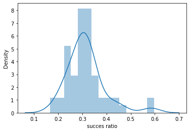

```python
sns.distplot(Data['succes ratio']);
```

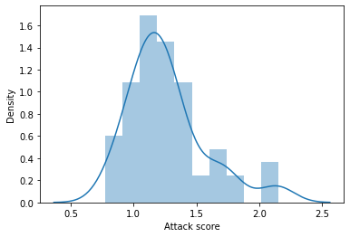

```python
sns.distplot(Data['Attack score'])
```

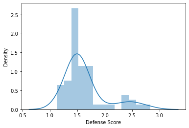

```python
sns.distplot(Data['Defense Score'])
```

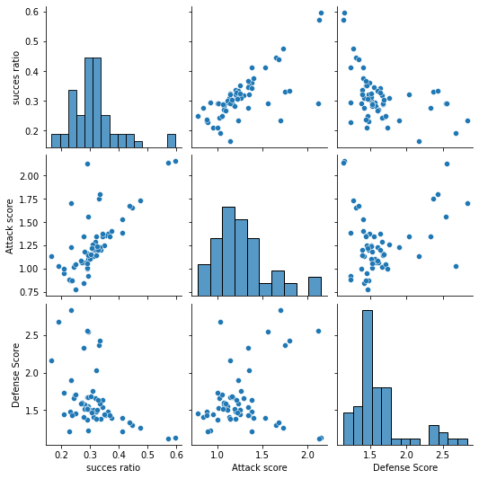

```python
sns.pairplot(Data[['succes ratio', 'Attack score', 'Defense Score']])
```

A better team is one which has a better Success ratio. As per the graphs above. There is an upward trend for teams with high baskets and less baskets given(defensiveness)

```python
s=['Team','succes ratio','Attack score','Defense Score','TeamLaunch']
Data[s]
```

|  | Team | succes ratio | Attack score | Defense Score | TeamLaunch |
| --- | --- | --- | --- | --- | --- |
| 0 | Team 1 | 0.596307 | 2.153150 | 1.136857 | 1929 |
| 1 | Team 2 | 0.572411 | 2.136133 | 1.127444 | 1929 |
| 2 | Team 3 | 0.474751 | 1.734507 | 1.265876 | 1929 |
| 3 | Team 4 | 0.445571 | 1.650901 | 1.302177 | 1931 |
| 4 | Team 5 | 0.437726 | 1.676684 | 1.339609 | 1929 |
| 5 | Team 6 | 0.411130 | 1.528239 | 1.400748 | 1934 |
| 6 | Team 7 | 0.361005 | 1.374334 | 1.480960 | 1929 |
| 7 | Team 8 | 0.375326 | 1.402259 | 1.403128 | 1929 |
| 8 | Team 9 | 0.351460 | 1.350957 | 1.433535 | 1939 |
| 9 | Team 10 | 0.350694 | 1.249421 | 1.442130 | 1932 |
| 10 | Team 11 | 0.367974 | 1.341176 | 1.430065 | 1941 |
| 11 | Team 12 | 0.345112 | 1.341578 | 1.545347 | 1939 |
| 12 | Team 13 | 0.315825 | 1.205321 | 1.487040 | 1948 |
| 13 | Team 14 | 0.317227 | 1.290616 | 1.658263 | 1929 |
| 14 | Team 15 | 0.323045 | 1.202332 | 1.475995 | 1944 |
| 15 | Team 16 | 0.323217 | 1.138088 | 1.391502 | 1935 |
| 16 | Team 17 | 0.310757 | 1.132271 | 1.404781 | 1949 |
| 17 | Team 18 | 0.342282 | 1.377517 | 1.636745 | 1933 |
| 18 | Team 19 | 0.337045 | 1.196356 | 1.387652 | 1960 |
| 19 | Team 20 | 0.334854 | 1.229015 | 1.593066 | 1951 |
| 20 | Team 21 | 0.411765 | 1.380805 | 1.221362 | 1998 |
| 21 | Team 22 | 0.293801 | 1.103774 | 1.559299 | 1941 |
| 22 | Team 23 | 0.289877 | 1.165644 | 1.668712 | 1977 |
| 23 | Team 24 | 0.299410 | 1.106195 | 1.507375 | 1959 |
| 24 | Team 25 | 0.322368 | 1.140351 | 1.388158 | 2004 |
| 25 | Team 26 | 0.292994 | 1.140127 | 1.671975 | 1935 |
| 26 | Team 27 | 0.313765 | 1.253036 | 1.506073 | 1961 |
| 27 | Team 28 | 0.247440 | 1.035836 | 1.692833 | 1940 |
| 28 | Team 29 | 0.328947 | 1.205263 | 1.639474 | 1930 |
| 29 | Team 30 | 0.281095 | 1.069652 | 1.572139 | 1963 |
| 30 | Team 31 | 0.290780 | 0.997636 | 1.373522 | 1974 |
| 31 | Team 32 | 0.302817 | 1.154930 | 1.690141 | 1943 |
| 32 | Team 33 | 0.232143 | 0.877232 | 1.477679 | 1977 |
| 33 | Team 34 | 0.277457 | 0.841040 | 1.413295 | 1987 |
| 34 | Team 35 | 0.308383 | 1.254491 | 1.760479 | 1941 |
| 35 | Team 36 | 0.281481 | 1.185185 | 1.518519 | 1991 |
| 36 | Team 37 | 0.271930 | 1.070175 | 1.605263 | 2007 |
| 37 | Team 38 | 0.290780 | 1.010638 | 1.524823 | 1962 |
| 38 | Team 39 | 0.325000 | 1.243750 | 1.506250 | 1994 |
| 39 | Team 40 | 0.268817 | 1.086022 | 1.591398 | 1978 |
| 40 | Team 41 | 0.289216 | 1.058824 | 1.519608 | 1971 |
| 41 | Team 42 | 0.294444 | 0.916667 | 1.227778 | 1963 |
| 42 | Team 43 | 0.243421 | 1.019737 | 1.664474 | 1999 |
| 43 | Team 44 | 0.307018 | 1.219298 | 1.464912 | 2014 |
| 44 | Team 45 | 0.330769 | 1.746154 | 2.369231 | 1929 |
| 45 | Team 46 | 0.228070 | 0.885965 | 1.219298 | 1990 |
| 46 | Team 47 | 0.293103 | 1.560345 | 2.543103 | 1947 |
| 47 | Team 48 | 0.250000 | 0.775000 | 1.462500 | 1996 |
| 48 | Team 49 | 0.237500 | 0.875000 | 1.437500 | 1995 |
| 49 | Team 50 | 0.277778 | 1.342593 | 2.333333 | 1945 |
| 50 | Team 51 | 0.322222 | 1.344444 | 2.033333 | 1953 |
| 51 | Team 52 | 0.291667 | 2.125000 | 2.555556 | 1929 |
| 52 | Team 53 | 0.250000 | 1.044118 | 1.705882 | 1979 |
| 53 | Team 54 | 0.333333 | 1.796296 | 2.425926 | 1929 |
| 54 | Team 55 | 0.191176 | 1.029412 | 2.676471 | 1950 |
| 55 | Team 56 | 0.210526 | 0.947368 | 1.447368 | 2016 |
| 56 | Team 57 | 0.210526 | 1.000000 | 1.736842 | 2009 |
| 57 | Team 58 | 0.233333 | 1.233333 | 1.900000 | 1956 |
| 58 | Team 59 | 0.233333 | 1.700000 | 2.833333 | 1951 |
| 59 | Team 60 | 0.166667 | 1.133333 | 2.166667 | 1955 |

```python
Data[s].sort_values(['succes ratio','Attack score','Defense Score','TeamLaunch'],ascending=(0,0,1,0))
```

|  | Team | succes ratio | Attack score | Defense Score | TeamLaunch |
| --- | --- | --- | --- | --- | --- |
| 0 | Team 1 | 0.596307 | 2.153150 | 1.136857 | 1929 |
| 1 | Team 2 | 0.572411 | 2.136133 | 1.127444 | 1929 |
| 2 | Team 3 | 0.474751 | 1.734507 | 1.265876 | 1929 |
| 3 | Team 4 | 0.445571 | 1.650901 | 1.302177 | 1931 |
| 4 | Team 5 | 0.437726 | 1.676684 | 1.339609 | 1929 |
| 20 | Team 21 | 0.411765 | 1.380805 | 1.221362 | 1998 |
| 5 | Team 6 | 0.411130 | 1.528239 | 1.400748 | 1934 |
| 7 | Team 8 | 0.375326 | 1.402259 | 1.403128 | 1929 |
| 10 | Team 11 | 0.367974 | 1.341176 | 1.430065 | 1941 |
| 6 | Team 7 | 0.361005 | 1.374334 | 1.480960 | 1929 |
| 8 | Team 9 | 0.351460 | 1.350957 | 1.433535 | 1939 |
| 9 | Team 10 | 0.350694 | 1.249421 | 1.442130 | 1932 |
| 11 | Team 12 | 0.345112 | 1.341578 | 1.545347 | 1939 |
| 17 | Team 18 | 0.342282 | 1.377517 | 1.636745 | 1933 |
| 18 | Team 19 | 0.337045 | 1.196356 | 1.387652 | 1960 |
| 19 | Team 20 | 0.334854 | 1.229015 | 1.593066 | 1951 |
| 53 | Team 54 | 0.333333 | 1.796296 | 2.425926 | 1929 |
| 44 | Team 45 | 0.330769 | 1.746154 | 2.369231 | 1929 |
| 28 | Team 29 | 0.328947 | 1.205263 | 1.639474 | 1930 |
| 38 | Team 39 | 0.325000 | 1.243750 | 1.506250 | 1994 |
| 15 | Team 16 | 0.323217 | 1.138088 | 1.391502 | 1935 |
| 14 | Team 15 | 0.323045 | 1.202332 | 1.475995 | 1944 |
| 24 | Team 25 | 0.322368 | 1.140351 | 1.388158 | 2004 |
| 50 | Team 51 | 0.322222 | 1.344444 | 2.033333 | 1953 |
| 13 | Team 14 | 0.317227 | 1.290616 | 1.658263 | 1929 |
| 12 | Team 13 | 0.315825 | 1.205321 | 1.487040 | 1948 |
| 26 | Team 27 | 0.313765 | 1.253036 | 1.506073 | 1961 |
| 16 | Team 17 | 0.310757 | 1.132271 | 1.404781 | 1949 |
| 34 | Team 35 | 0.308383 | 1.254491 | 1.760479 | 1941 |
| 43 | Team 44 | 0.307018 | 1.219298 | 1.464912 | 2014 |
| 31 | Team 32 | 0.302817 | 1.154930 | 1.690141 | 1943 |
| 23 | Team 24 | 0.299410 | 1.106195 | 1.507375 | 1959 |
| 41 | Team 42 | 0.294444 | 0.916667 | 1.227778 | 1963 |
| 21 | Team 22 | 0.293801 | 1.103774 | 1.559299 | 1941 |
| 46 | Team 47 | 0.293103 | 1.560345 | 2.543103 | 1947 |
| 25 | Team 26 | 0.292994 | 1.140127 | 1.671975 | 1935 |
| 51 | Team 52 | 0.291667 | 2.125000 | 2.555556 | 1929 |
| 37 | Team 38 | 0.290780 | 1.010638 | 1.524823 | 1962 |
| 30 | Team 31 | 0.290780 | 0.997636 | 1.373522 | 1974 |
| 22 | Team 23 | 0.289877 | 1.165644 | 1.668712 | 1977 |
| 40 | Team 41 | 0.289216 | 1.058824 | 1.519608 | 1971 |
| 35 | Team 36 | 0.281481 | 1.185185 | 1.518519 | 1991 |
| 29 | Team 30 | 0.281095 | 1.069652 | 1.572139 | 1963 |
| 49 | Team 50 | 0.277778 | 1.342593 | 2.333333 | 1945 |
| 33 | Team 34 | 0.277457 | 0.841040 | 1.413295 | 1987 |
| 36 | Team 37 | 0.271930 | 1.070175 | 1.605263 | 2007 |
| 39 | Team 40 | 0.268817 | 1.086022 | 1.591398 | 1978 |
| 52 | Team 53 | 0.250000 | 1.044118 | 1.705882 | 1979 |
| 47 | Team 48 | 0.250000 | 0.775000 | 1.462500 | 1996 |
| 27 | Team 28 | 0.247440 | 1.035836 | 1.692833 | 1940 |
| 42 | Team 43 | 0.243421 | 1.019737 | 1.664474 | 1999 |
| 48 | Team 49 | 0.237500 | 0.875000 | 1.437500 | 1995 |
| 58 | Team 59 | 0.233333 | 1.700000 | 2.833333 | 1951 |
| 57 | Team 58 | 0.233333 | 1.233333 | 1.900000 | 1956 |
| 32 | Team 33 | 0.232143 | 0.877232 | 1.477679 | 1977 |
| 45 | Team 46 | 0.228070 | 0.885965 | 1.219298 | 1990 |
| 56 | Team 57 | 0.210526 | 1.000000 | 1.736842 | 2009 |
| 55 | Team 56 | 0.210526 | 0.947368 | 1.447368 | 2016 |
| 54 | Team 55 | 0.191176 | 1.029412 | 2.676471 | 1950 |
| 59 | Team 60 | 0.166667 | 1.133333 | 2.166667 | 1955 |

will not consider the teams before 1935 which are already establised,consdiering the teams with least highest succes ratio, highest Attack score and least Defense Score.

Idea is to consider the teams on a player performance level to understand which team is a better attacking and defensive player. Most basked scored per games will give an understanding on which team is better as an attacking team.Similalry, team with least basket given per Game is a better defensice team. We need a team which is good with defence and attack. Will also consider the success ratios as well.

Hence, after sorting based on such criteria. will reccomend Team 21.

3.

Quality- TeamLaunch data is not in a matching format. it is not clear the exac year of team launch. hence, taking assumptions. Team 61 with no data at all for analysis.

Quantity- More details on the type of matches played. the finals and the regular games played. More quantity such information and matching wins, lossed will help us understand which teams play better under pressure.

Variety- Baskets and score should be based on time as teams that has played on more over times will have more basket scoring and basket giving attempts. More info on the minutes played by team.

Velocity-More data on position held by the team in recent years ll be helpful. the data set is weak on time line. with out recent peroformance, it is difficult to come to a proper conclusion. information over the years would be beneficial to know if the team owners alway kept a good team and how the team perfomances varied over the years.

Veracity-there is a score column which is lesser than the basket scored, the total score should be greated than the baskets socred as there are points of 2 and 3. that doubts the authenticity of that column.

Part 3

```python
import numpy as np
import pandas as pd
import seaborn as sns
import matplotlib.pyplot as plt
from scipy import stats
```

```python
df = pd.read_csv('download-2.csv')
```

```python
df.dtypes
```

```
Startup           object
Product           object
Funding           object
Event             object
Result            object
OperatingState    object
dtype: object
```

```python
df.head()
```

|  | Startup | Product | Funding | Event | Result | OperatingState |
| --- | --- | --- | --- | --- | --- | --- |
| 0 | 2600Hz | 2600hz.com | NaN | Disrupt SF 2013 | Contestant | Operating |
| 1 | 3DLT | 3dlt.com | $630K | Disrupt NYC 2013 | Contestant | Closed |
| 2 | 3DPrinterOS | 3dprinteros.com | NaN | Disrupt SF 2016 | Contestant | Operating |
| 3 | 3Dprintler | 3dprintler.com | $1M | Disrupt NY 2016 | Audience choice | Operating |
| 4 | 42 Technologies | 42technologies.com | NaN | Disrupt NYC 2013 | Contestant | Operating |

```python
df.isnull().values.any()
```

```
True
```

```python
df.isnull().sum()
```

```
Startup             0
Product             6
Funding           214
Event               0
Result              0
OperatingState      0
dtype: int64
```

```python
df.dropna(inplace=True)  # Drops all the rows that have atleast one missing values
df.isnull().sum()
```

```
Startup           0
Product           0
Funding           0
Event             0
Result            0
OperatingState    0
dtype: int64
```

```python
df.loc[:,'Funds_in_million'] = df['Funding'].apply(lambda x:
float(x[1:-1])/1000 if x[-1] == 'K' else (float(x[1:-1])*1000 if
x[-1] == 'B' else float(x[1:-1])))
```

```python
df
```

|  | Startup | Product | Funding | Event | Result | OperatingState | Funds_in_million |
| --- | --- | --- | --- | --- | --- | --- | --- |
| 1 | 3DLT | 3dlt.com | $630K | Disrupt NYC 2013 | Contestant | Closed | 0.63 |
| 3 | 3Dprintler | 3dprintler.com | $1M | Disrupt NY 2016 | Audience choice | Operating | 1.00 |
| 5 | 5to1 | 5to1.com | $19.3M | TC50 2009 | Contestant | Acquired | 19.30 |
| 6 | 8 Securities | 8securities.com | $29M | Disrupt Beijing 2011 | Finalist | Operating | 29.00 |
| 10 | AdhereTech | adheretech.com | $1.8M | Hardware Battlefield 2014 | Contestant | Operating | 1.80 |
| ... | ... | ... | ... | ... | ... | ... | ... |
| 657 | Zivity | zivity.com | $8M | TC40 2007 | Contestant | Operating | 8.00 |
| 658 | Zmorph | zmorph3d.com | $1M | - | Audience choice | Operating | 1.00 |
| 659 | Zocdoc | zocdoc.com | $223M | TC40 2007 | Contestant | Operating | 223.00 |
| 660 | Zula | zulaapp.com | $3.4M | Disrupt SF 2013 | Audience choice | Operating | 3.40 |
| 661 | Zumper | zumper.com | $31.5M | Disrupt SF 2012 | Finalist | Operating | 31.50 |

446 rows × 7 columns

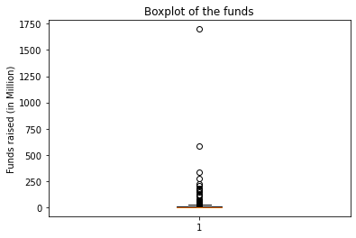

```python
from matplotlib import pyplot as plt

plot = plt.boxplot(df.Funds_in_million)
plt.title('Boxplot of the funds')
plt.ylabel("Funds raised (in Million)")

plt.show()
```

```python
upper_fence = plot['caps'][1].get_data()[1][1]   # we can use the values from the box plot itself to get the upper fence
upper_fence
```

```
22.0
```

```python
print(f'Number of outliers = {len(df[df.Funds_in_million > upper_fence])}')

df[df.Funds_in_million > upper_fence]
```

```
Number of outliers = 60
```

|  | Startup | Product | Funding | Event | Result | OperatingState | Funds_in_million |
| --- | --- | --- | --- | --- | --- | --- | --- |
| 6 | 8 Securities | 8securities.com | $29M | Disrupt Beijing 2011 | Finalist | Operating | 29.0 |
| 31 | Anyclip | anyclip.com | $24M | TC50 2009 | Finalist | Operating | 24.0 |
| 40 | Artsy | artsy.net | $50.9M | Disrupt NYC 2010 | Contestant | Operating | 50.9 |
| 49 | Badgeville | badgeville.com | $40M | Disrupt SF 2010 | Finalist | Acquired | 40.0 |
| 56 | Betterment | betterment.com | $205M | Disrupt NYC 2010 | Finalist | Operating | 205.0 |
| 108 | Clickable | clickable.com | $32.5M | TC40 2007 | Finalist | Acquired | 32.5 |
| 113 | Cloudflare | cloudflare.com | $182.1M | Disrupt SF 2010 | Runner up | Operating | 182.1 |
| 128 | Credit Sesame | creditsesame.com | $35.4M | Disrupt SF 2010 | Contestant | Operating | 35.4 |
| 130 | CrowdFlower Inc. | crowdflower.com | $38M | TC50 2009 | Contestant | Operating | 38.0 |
| 132 | Cubic Telecom | cubictelecom.com | $37.1M | TC40 2007 | Contestant | Operating | 37.1 |
| 138 | DataSift | datasift.com | $72M | Disrupt SF 2010 | Finalist | Operating | 72.0 |
| 139 | DataXu | dataxu.com | $64M | TC50 2009 | Contestant | Operating | 64.0 |
| 154 | Dropbox | dropbox.com | $1.7B | TC50 2008 | Contestant | Operating | 1700.0 |
| 166 | Enigma | enigma.io | $34.6M | Disrupt NYC 2013 | Winner | Operating | 34.6 |
| 172 | EverythingMe | everything.me | $35.5M | Disrupt NYC 2011 | Contestant | Closed | 35.5 |
| 179 | Famo.us | famo.us | $30.1M | Disrupt SF 2012 | Contestant | Operating | 30.1 |
| 180 | Farmigo | farmigo.com | $26M | Disrupt SF 2011 | Finalist | Operating | 26.0 |
| 188 | Fitbit | fitbit.com | $66M | TC50 2008 | Finalist | Ipo | 66.0 |
| 191 | Flock | flock.com | $28.3M | TC40 2007 | Contestant | Acquired | 28.3 |
| 209 | Getaround | getaround.com | $103M | Disrupt NYC 2011 | Winner | Operating | 103.0 |
| 213 | Gild | gild.com | $25.9M | Disrupt SF 2010 | Contestant | Acquired | 25.9 |
| 215 | Glide | glide.me | $36.5M | Disrupt NYC 2013 | Audience choice | Operating | 36.5 |
| 225 | Grockit | grockit.com | $44.7M | TC50 2008 | Finalist | Acquired | 44.7 |
| 231 | HackerRank | hackerrank.com | $24.2M | Disrupt SF 2012 | Contestant | Operating | 24.2 |
| 271 | Ionic Security | ionicsecurity.com | $122.4M | Disrupt SF 2012 | Contestant | Operating | 122.4 |
| 276 | IZEA | izea.com | $34.9M | Disrupt NYC 2010 | Contestant | Ipo | 34.9 |
| 279 | Jiff | jiff.com | $67.8M | Disrupt SF 2011 | Contestant | Acquired | 67.8 |
| 282 | Kaltura | kaltura.com | $166.1M | TC40 2007 | Audience choice | Operating | 166.1 |
| 302 | Layer | layer.com | $42.1M | Disrupt SF 2013 | Winner | Operating | 42.1 |
| 305 | LearnVest | learnvest.com | $69M | TC50 2009 | Contestant | Acquired | 69.0 |
| 313 | LiveIntent | liveintent.com | $65.1M | Disrupt NYC 2010 | Audience choice | Operating | 65.1 |
| 325 | Lystable | lystable.com | $25.1M | Disrupt London 2015 | Finalist | Operating | 25.1 |
| 346 | Mint | mint.com | $31.8M | TC40 2007 | Winner | Acquired | 31.8 |
| 389 | OrderWithMe | orderwithme.com | $37M | Disrupt Beijing 2011 | Winner | Operating | 37.0 |
| 393 | Osmo | playosmo.com | $38.5M | Disrupt SF 2013 | Contestant | Operating | 38.5 |
| 394 | Ossia | ossia.com | $25.5M | Disrupt SF 2013 | Runner up | Operating | 25.5 |
| 398 | Owlet Baby Care | owletcare.com | $24M | Hardware Battlefield 2014 | Runner up | Operating | 24.0 |
| 427 | Postmates | postmates.com | $278M | Disrupt SF 2011 | Contestant | Operating | 278.0 |
| 432 | Prism Skylabs | prism.com | $24M | Disrupt SF 2011 | Runner up | Operating | 24.0 |
| 435 | PubMatic | pubmatic.com | $63M | TC40 2007 | Contestant | Operating | 63.0 |
| 460 | Roadie | roadie.com | $25M | Disrupt NYC 2014 | Audience choice | Operating | 25.0 |
| 471 | SeatGeek | seatgeek.com | $160M | TC50 2009 | Contestant | Operating | 160.0 |
| 546 | StyleSeat | styleseat.com | $40M | Disrupt NYC 2011 | Contestant | Operating | 40.0 |
| 555 | Symphony Commerce | symphonycommerce.com | $47.4M | Disrupt NYC 2011 | Contestant | Operating | 47.4 |
| 560 | Talkdesk | talkdesk.com | $24.5M | Disrupt NYC 2012 | Contestant | Operating | 24.5 |
| 581 | TouchPal | touchpal.com | $25M | Disrupt Beijing 2011 | Finalist | Operating | 25.0 |
| 593 | TrueCar | truecar.com | $332.4M | TC50 2008 | Contestant | Ipo | 332.4 |
| 598 | UberConference | uberconference.com | $35M | Disrupt NYC 2012 | Winner | Operating | 35.0 |
| 606 | Upwork | upwork.com | $168.8M | TC50 2009 | Audience choice | Operating | 168.8 |
| 615 | VideoSurf | videosurf.com | $28M | TC50 2008 | Contestant | Acquired | 28.0 |
| 625 | Voxy | voxy.com | $30.8M | Disrupt SF 2010 | Contestant | Operating | 30.8 |
| 643 | Xobni | yahoo.com | $41.8M | TC40 2007 | Contestant | Acquired | 41.8 |
| 644 | Yammer | yammer.com | $142M | TC50 2008 | Winner | Acquired | 142.0 |
| 647 | Yext | yext.com | $117.8M | TC50 2009 | Contestant | Ipo | 117.8 |
| 649 | YouNow | younow.com | $26M | Disrupt SF 2011 | Contestant | Operating | 26.0 |
| 650 | YourMechanic | yourmechanic.com | $28M | Disrupt SF 2012 | Winner | Operating | 28.0 |
| 654 | ZEFR | zefr.com | $62.1M | Disrupt NYC 2010 | Contestant | Operating | 62.1 |
| 656 | Zenefits | zenefits.com | $583.6M | Disrupt NYC 2013 | Finalist | Operating | 583.6 |
| 659 | Zocdoc | zocdoc.com | $223M | TC40 2007 | Contestant | Operating | 223.0 |
| 661 | Zumper | zumper.com | $31.5M | Disrupt SF 2012 | Finalist | Operating | 31.5 |

```python
df.drop(df[df.Funds_in_million > upper_fence].index, inplace = True)
```

```python
df.OperatingState.value_counts()
```

```
Operating    275
Closed        56
Acquired      55
Name: OperatingState, dtype: int64
```

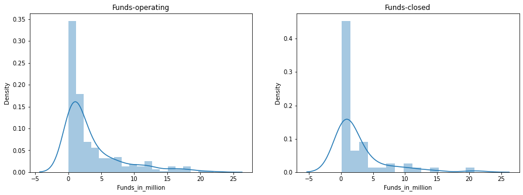

```python
fig, ax = plt.subplots(1, 2)

fig.set_figheight(5)
fig.set_figwidth(15)

sns.distplot(df.loc[df.OperatingState == 'Operating', 'Funds_in_million'], ax = ax[0])
sns.distplot(df.loc[df.OperatingState =='Closed', 'Funds_in_million'], ax = ax[1])

ax[0].set_title('Funds-operating')
ax[1].set_title('Funds-closed')
plt.show()
```

```python
#Null hypothesis  : There is no difference between the two means
#Alternate hypothesis : There is significant difference between the two means
```

```python
from statsmodels.stats.weightstats import ztest

sample1 = df.loc[df.OperatingState == 'Operating', 'Funds_in_million']
sample2 = df.loc[df.OperatingState =='Closed', 'Funds_in_million']

alpha = 0.05   # Let's consider a significance level of 5%

test_statistic, p_value = ztest(sample1, sample2)
print(p_value)
print(alpha)

if p_value <= alpha:
    print("rejecting null hypothesis:p_value <= alpha")

else:
    print("we fail to reject the Null hypothesis p_value > alpha")
```

```
0.1922631485716917
0.05
we fail to reject the Null hypothesis p_value > alpha
```

```python
df1 = df.copy(deep = True)
df1
```

|  | Startup | Product | Funding | Event | Result | OperatingState | Funds_in_million |
| --- | --- | --- | --- | --- | --- | --- | --- |
| 1 | 3DLT | 3dlt.com | $630K | Disrupt NYC 2013 | Contestant | Closed | 0.63 |
| 3 | 3Dprintler | 3dprintler.com | $1M | Disrupt NY 2016 | Audience choice | Operating | 1.00 |
| 5 | 5to1 | 5to1.com | $19.3M | TC50 2009 | Contestant | Acquired | 19.30 |
| 10 | AdhereTech | adheretech.com | $1.8M | Hardware Battlefield 2014 | Contestant | Operating | 1.80 |
| 11 | AdRocket | adrocket.com | $1M | TC50 2008 | Contestant | Closed | 1.00 |
| ... | ... | ... | ... | ... | ... | ... | ... |
| 645 | Yap | yapme.com | $10M | TC40 2007 | Contestant | Closed | 10.00 |
| 646 | YayPay Inc | yaypay.com | $900K | Disrupt London 2015 | Contestant | Operating | 0.90 |
| 657 | Zivity | zivity.com | $8M | TC40 2007 | Contestant | Operating | 8.00 |
| 658 | Zmorph | zmorph3d.com | $1M | - | Audience choice | Operating | 1.00 |
| 660 | Zula | zulaapp.com | $3.4M | Disrupt SF 2013 | Audience choice | Operating | 3.40 |

386 rows × 7 columns

```python
df1.Result.value_counts()
```

```
Contestant         282
Finalist            52
Audience choice     20
Winner              17
Runner up           15
Name: Result, dtype: int64
```

```python
winners = df1.Result.value_counts()[1:].sum()
contestants = df1.Result.value_counts()['Contestant']
```

```python
contestants_operating = df1.OperatingState[df1.Result == 'Contestant'].value_counts().loc['Operating']
winners_operating = df1.OperatingState[df1.Result != 'Contestant'].value_counts().loc['Operating']
```

```python
((winners_operating/winners)*100), ((contestants_operating/contestants*100))
```

```
(77.88461538461539, 68.79432624113475)
```

```python
#Null hyputhesis: The proportion of companies that are operating is the same for winners and contestants
#Alternative hypothesis: The proportion of companies that are operating is different for winners and contestants
```

```python
from statsmodels.stats.proportion import proportions_ztest

test_statistic, p_value = proportions_ztest([contestants_operating, winners_operating], [contestants, winners])

print(p_value)
print(alpha)
if p_value <= alpha:
    print('the difference is significant and we reject the Null hypothesis')
else:
    print('p_value> alpha we fail to reject the Null hypothesis')
```

```
0.08001635475470781
0.05
p_value> alpha we fail to reject the Null hypothesis
```

```python
df[df.Event.apply(lambda x: 'Disrupt' in x)].Event.value_counts()
```

```
Disrupt NY 2015         21
Disrupt NYC 2013        19
Disrupt SF 2014         19
Disrupt SF 2015         19
Disrupt SF 2013         19
Disrupt SF 2011         19
Disrupt NYC 2012        19
Disrupt SF 2016         17
Disrupt NY 2016         16
Disrupt NYC 2011        15
Disrupt SF 2012         15
Disrupt NYC 2014        15
Disrupt SF 2010         13
Disrupt London 2015     11
Disrupt London 2016     10
Disrupt EU 2014         10
Disrupt NYC 2010        10
Disrupt EU 2013          9
Disrupt Beijing 2011     4
Name: Event, dtype: int64
```

PART 1

```python
#question 1 A

import math

m=400
n= 2000

round(m/n,4)
```

```
0.2
```

```python
#question 1 B

#a=actually placed an order
#b=planned to purchase

pab=400/2000
pb=500/2000

round(pab/pb,4)
```

```
0.8
```

```python
import numpy as np
import pandas as pd
import scipy.stats as stats
import matplotlib.pyplot as plt
```

```python
#outout is yes/no(binary) hence, binomial distribution
n=10
p=0.05

k=np.arange(0,11)
binomial=stats.binom.pmf(k,n,p)
binomial
```

```
array([5.98736939e-01, 3.15124705e-01, 7.46347985e-02, 1.04750594e-02,
       9.64808106e-04, 6.09352488e-05, 2.67259863e-06, 8.03789063e-08,
       1.58642578e-09, 1.85546875e-11, 9.76562500e-14])
```

```python
#Q2.A
binomial[0]
```

```
0.5987369392383789
```

```python
#Q2.B
binomial[1]
```

```
0.31512470486230504
```

```python
cumm=stats.binom.cdf(k,n,p)
#Q2.C
cumm[2]
```

```
0.9884964426207031
```

```python
#Q2.D
1-cumm[2]
```

```
0.01150355737929687
```

```python
#event happening over a time space-poission Dist
l=3

n=np.arange(0,16)
poss=stats.poisson.cdf(n,l)
poss
```

```
array([0.04978707, 0.19914827, 0.42319008, 0.64723189, 0.81526324,
       0.91608206, 0.96649146, 0.9880955 , 0.99619701, 0.99889751,
       0.99970766, 0.99992861, 0.99998385, 0.9999966 , 0.99999933,
       0.99999988])
```

```python
#Q3.A
1-poss[0]
```

```
0.950212931632136
```

```python
#Q3.B
poss[4]-poss[1]
```

```
0.6161149710523164
```

```
<function matplotlib.pyplot.show(close=None, block=None)>
```

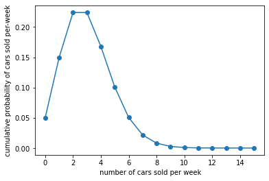

```python
#Q3.C
poss=stats.poisson.pmf(n,l)
plt.plot(n,poss,'o-')
plt.xlabel(" number of cars sold per week")
plt.ylabel("cumulative probability of cars sold per-week")
plt.show
```

```python
n=3
p=0.868

k=np.arange(0,4)
binomial=stats.binom.pmf(k,n,p)
binomial
```

```
array([0.00229997, 0.0453721 , 0.2983559 , 0.65397203])
```

```python
#question 4 A x=3
binomial[3]
```

```
0.653972032
```

```python
#question 4 B x=0

binomial[0]
```

```
0.002299968
```

```python
#question 4 C

#Q=P(x>=2)=p(x=2)+p(x=3)
Q=binomial[2]+binomial[3]
Q
```

```
0.9523279359999999
```

# question 5- Explaining one scenario for concepts leanred in stats module

# 1.Ecommerce platforms using binomial distribution to find the probability of online transactions are that are fraudulent.(fraud-yes/no)

# If it is known that 1% of the online transactions are fraudulent.

# If there are 100 transactions. corresponding number of fraud transaction probability can be calculated

# 2.Numnber of people visiting an online store. the numberof visitors per hour can be predicted using poisson distribution.

# 3 Normal distribution: Distribution of marks, shoe or dress sizes in a class can be found